# SOGP Values and Ethics Course Evaluation

2021-09-05

# Introduction

This is the report on the outcome of the course evaluation data provided by participants.

# Responses

## Whether the content was found to be too challenging

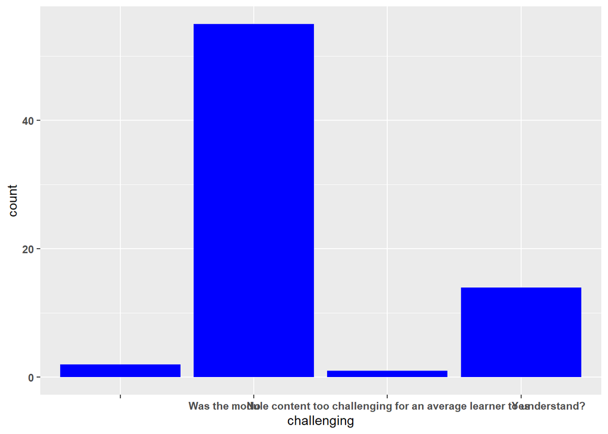

## Wether the ideas expressed seemed too distant

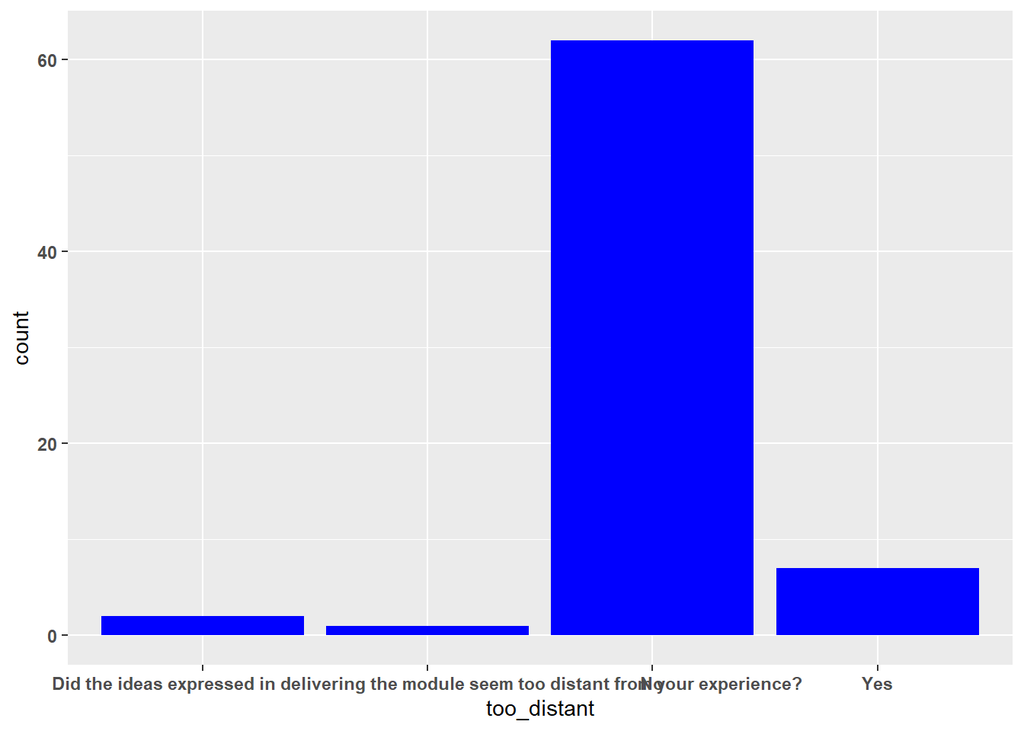

## Rating on class duration

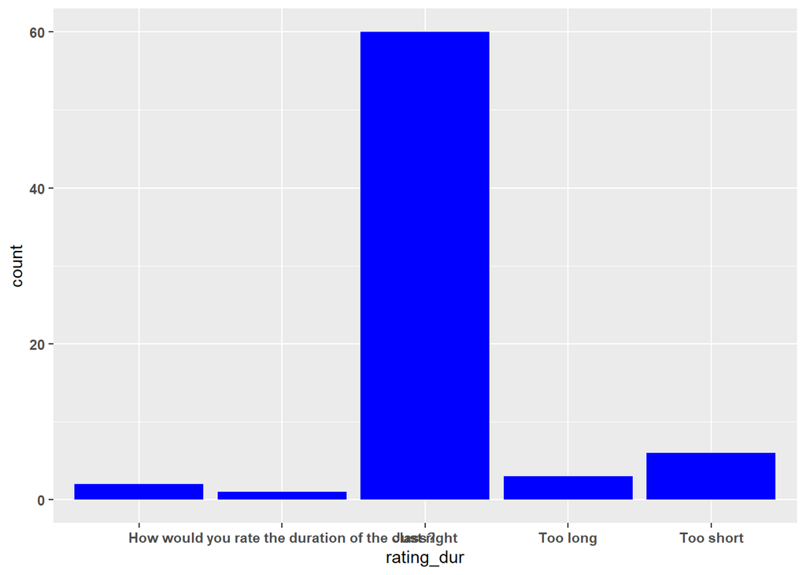

## Recommended duration of class

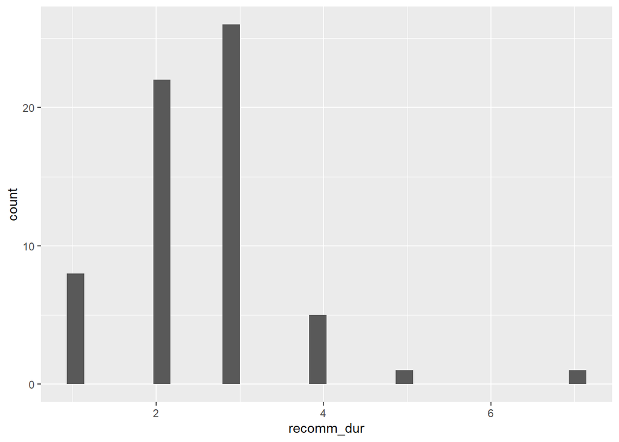

## Communication skills of facilitator

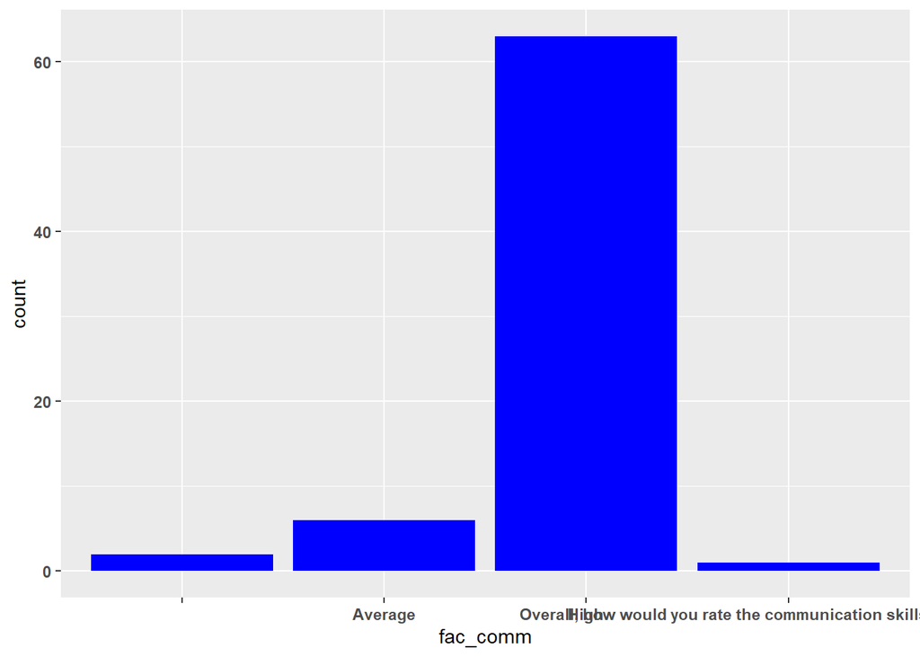

## Feel comfortable expressing oneself to facilitator

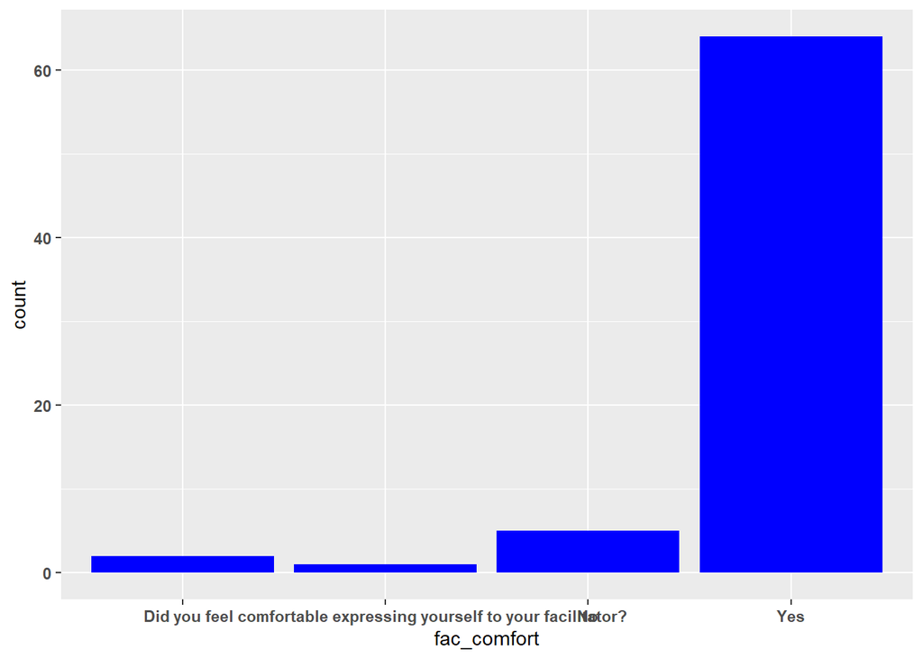

# Observations/Recommendation

1. The structure of the evaluation needs to be reviewed, but for future courses, since this one has already gone quite far. Many of the questions asked cannot be usefully analysed as they are presently.
2. The reporting needs to be structured in such a way that the reporting can be in a module by module basis.
3. There were some repetitions i.e. some students responded more than once for the same module.
4. It seems only few of the students completed the evaluation. A way should be devised to ensure close to 100% response rate. In this light, the evaluation data should equally be accompanied by attendance.
5. The evaluation should be anonymous. This will also encourage people to complete it. This change should be made to the form **now**.
6. The charts are still rudimentary, but will have to be improved upon over time, due to time constraints.